# Exercice 2

Damien BROSSAT & Yanael FEUILLET–GARCIA

2024-05-15

Enoncé :

On a relevé les pourcentages de satisfaction des cours reçus par des étudiants d’une école d’ingénieur. Les résultats des notes sur 100 sont les suivants :

74, 85, 95, 84, 68, 93, 84, 87, 78, 72, 81, 91, 80, 65, 76, 81, 97, 69, 70, 98.

#Question 1 :

Créer la séquence satisfaction avec la fonction c()

```r
satisfaction <- c(74, 85, 95, 84, 68, 93, 84, 87, 78, 72, 81, 91, 80, 65, 76, 81, 97, 69, 70, 98)
satisfaction
```

```
##  [1] 74 85 95 84 68 93 84 87 78 72 81 91 80 65 76 81 97 69 70 98
```

#Question 2 :

Afficher le tableau des effectifs et vérifier que chacune des modalités est égale à 1 avec la fonction table()

```r
satisfaction_table <- table(satisfaction)
satisfaction_table
```

```
## satisfaction
## 65 68 69 70 72 74 76 78 80 81 84 85 87 91 93 95 97 98
##  1  1  1  1  1  1  1  1  1  2  2  1  1  1  1  1  1  1
```

```r
all(satisfaction_table == 1)
```

```
## [1] FALSE
```

#Question 3 :

Combien de résultats ont été récoltés ? Utilisez une fonction R pour déterminer ce résultat

```r
num_results <- length(satisfaction)
num_results
```

```
## [1] 20
```

#Question 4 :

Afficher la visualisation boite à moustache de cette séquence. Retrouver les éléments clés grâce à la fonction summary() Visualiser l’histogramme de ces pourcentages de satisfcation avec 4 classes. Que pouvez-vous en dire ?

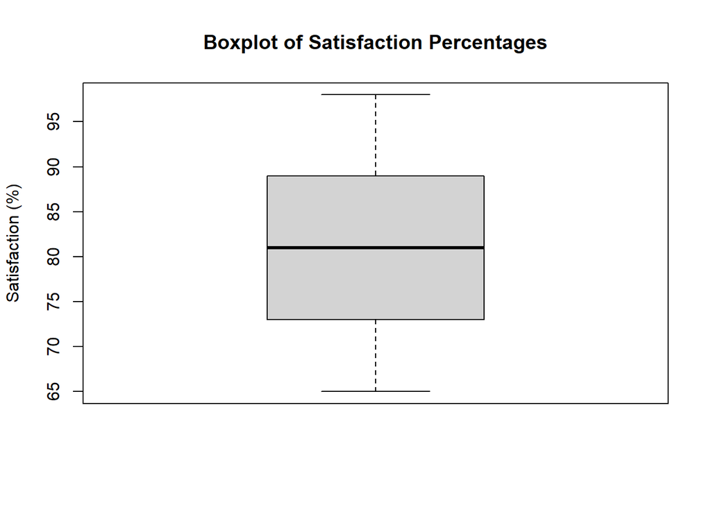

```r
boxplot(satisfaction, main = "Boxplot of Satisfaction Percentages", ylab = "Satisfaction (%)")
```

```r
summary_satisfaction <- summary(satisfaction)
summary_satisfaction
```

```
##    Min. 1st Qu.  Median    Mean 3rd Qu.    Max.
##    65.0    73.5    81.0    81.4    88.0    98.0
```

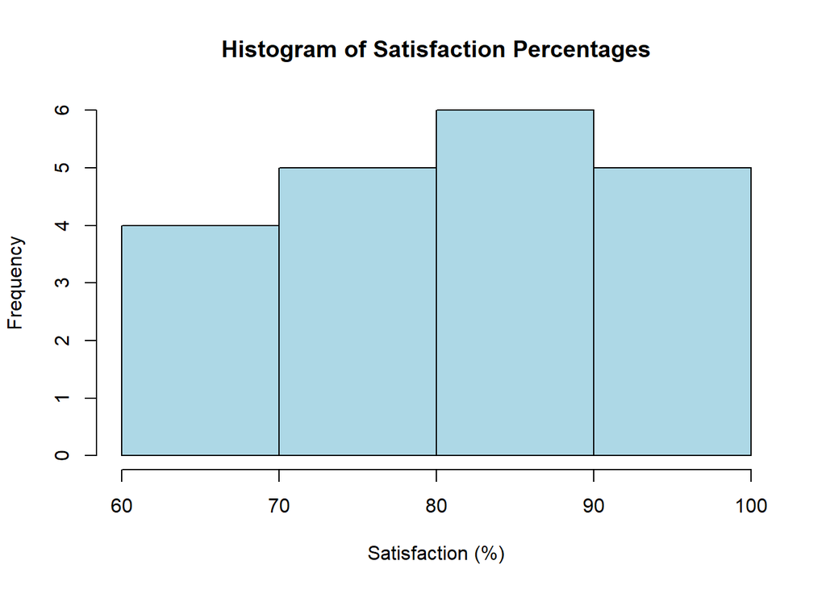

```r
hist(satisfaction, breaks = 4, main = "Histogram of Satisfaction Percentages", xlab = "Satisfaction (%)", col = "lightblue", border = "black")
```

Interprétation :

[output not shown]